# Southern New Hampshire University

[DRAFT] ReMap Experiment: No FAFSA (GR) Dialing

Karen West | k.west2@snhu.edu

Eric Gustafson | e.gustafson@snhu.edu

Updated: 2021-02-26

## Overview

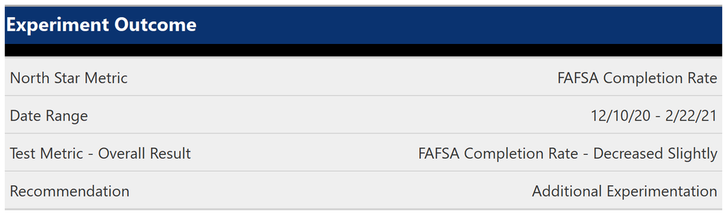

**Theory:** One of the biggest impediments to students who plan on using financial aid is their inability to quickly complete the Free Application for Federal Student Aid (FAFSA) as part of the admission process.

**Hypothesis:** Outreaching students who have not completed their FAFSA *increases* their likelihood to complete their FAFSA.

## Test Design

**Test Metric:** FAFSA Completion Rate, calculated as:
$$FAFSA Completion Rate = \sum_{n=FAFSA Complete} / \sum_{n=Total Eligible to Complete FAFSA}$$

**Testing Groups:** Of all eligible members of the population (full criteria list below), control and experiment groups were assigned according to testing cells on the Unify contact.

- Control Group: **50%** of eligible dialing list - these were *not dialed*
- Experiment Group: **50%** of eligible dialing list - these were *dialed*

Those in the experiment group were dialed weekly throughout the experiment timeframe with the exception of the final week prior to term start.

**Experiment Population Eligibility (AKA InPopulation):**

- GR prospective student with open Admission opportunity for the 21TW3 term
- In Applied, App In Progress or Accepted Stage
- Has not completed a 20/21 FAFSA or has only completed the “wrong” FAFSA year (only completed 21-22 FAFSA form and must complete 20-21)
- Prospective students that have not indicated their sole financial plan as being “Out of Pocket” or there is no financial plan indicated.
- Is not Course-Work Only (CWO) or a Guild student, or on the CMHC waitlist

## Outcomes & Learnings

### Experiment Results

- **Overall Results:** As of 2/24/21, the FAFSA completion rate for the test group was **0.9 percentage points lower (-3.6% change)**. This difference is not statistically significant at 95% confidence.
- **Completed FAFSA and Registered (Rate):** The percent of those in the population who completed a FAFSA and also registered was lower for the experiment group (**21.1%**) as compared to the control group (**22.1%**).

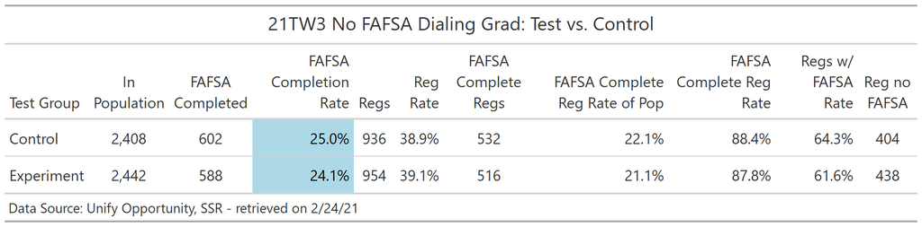

**NOTE:** Enroll rate considers Day 15 enrolls only (not shown yet)

### Learnings

- **Wrong FAFSA:** Those that originally submitted the wrong FAFSA (filled out 21-22 instead of 20-21) completed a FAFSA **more than three times** the rate (**72%** vs. **23%**) of anyone else in the population who did not fill out a FAFSA, but there was very little difference between test and control groups. This indicates that those prospective students who are engaged enough to complete one version of the FAFSA (albeit the “wrong” one), will complete the correct FAFSA on their own and appear unlikely to be influenced by outreach campaigns like this one. For reference, note that Undergrad “Wrong FAFSA” students only completed their FAFSAs at a rate of about two times higher than the rest of the population: No FAFSA UG Dialing 21EW3 Experiment]
- **Enrolls Without FAFSA:** **45%** of all enrollments that occurred within this population (Control + Experiment) enrolled without completing a FAFSA.

### Next Steps

*Additional Experimentation.*

## Glossary of Terms

**`FAFSA`** - Free Application for Federal Student Aid